# Missing Data

## Look at the distribution of one variable according to missing non-missing status for another variable using pbox

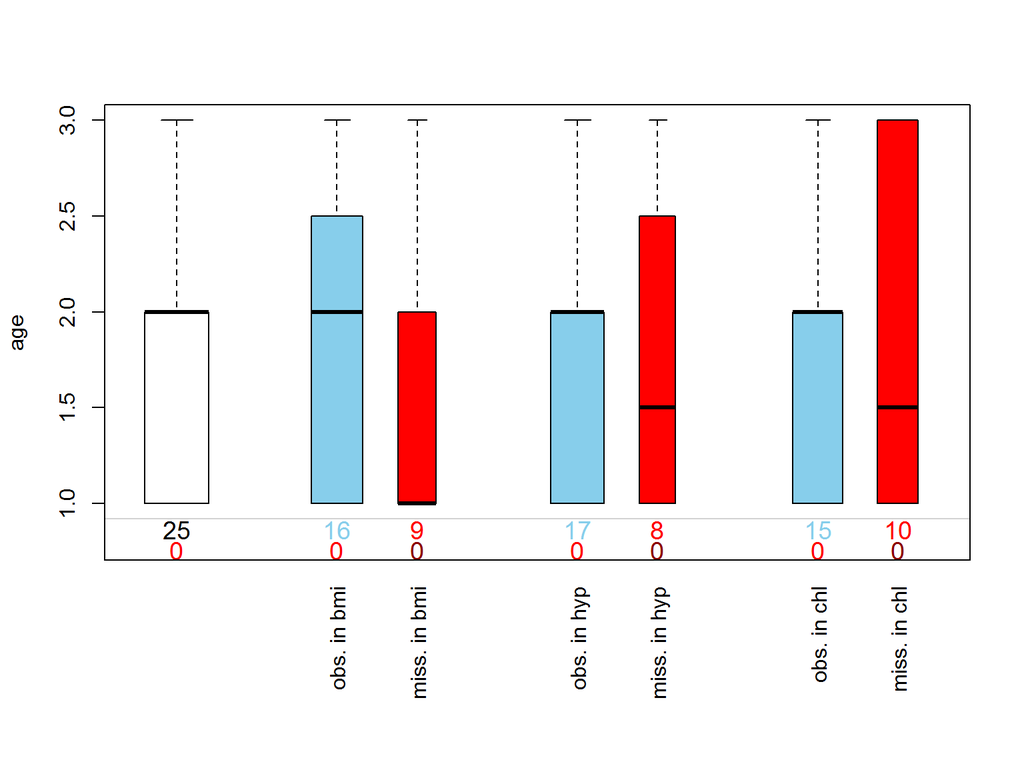

```r
pbox(nhanes,pos=1,int=FALSE,cex=1.2)
```

```r
#what do we see in this graph?
```

## How do we actually impute the missing data? Well we call the MICE function of course! All values that are missing are imputed using the other variables as predictors. There are ways to leave some variables out of the imputation (refer to the excellent resource:https://www.jstatsoft.org/article/view/v045i03

```r
imp<-mice(nhanes)
##look at imputation details. Note that by default 5 imputations are done so you end up with 5 datasets. This can be changed!
imp
```

```
## Multiply imputed data set
## Call:
## mice(data = nhanes)
## Number of multiple imputations:  5
## Missing cells per column:
## age bmi hyp chl
##   0   9   8  10
## Imputation methods:
##   age   bmi   hyp   chl
##    "" "pmm" "pmm" "pmm"
## VisitSequence:
## bmi hyp chl
##   2   3   4
## PredictorMatrix:
##     age bmi hyp chl
## age   0   0   0   0
## bmi   1   0   1   1
## hyp   1   1   0   1
## chl   1   1   1   0
## Random generator seed value:  NA
```

## Let’s look at the meaning of the output

- Imputations are generated by the default method for numerical data, which is called **pmm** or predictive mean matching
- The VisitSequence provides the order of imputation, which flows from left to right in the dataset unless you change it. The PredictorMatrix tells you what variables are being used to predict others. Age is not missing so nothing is being used to predict age. BMI is missing so age, hyp, and chl are being used to predict bmi, hyp is missing so age, bmi and chl are being used to predict hyp and so on. For information on what VisitSequence and PredictorMatrix, I refer to the excellent documentation on the MICE package (https://www.jstatsoft.org/article/view/v045i03).

## Diagnostics for imputation model: Are the imputed values plausible? Do we have any pregnant fathers (not really since this variable wasn’t in our dataset)?

```r
#check BMI
imp$imp$bmi
```

```
##       1    2    3    4    5
## 1  33.2 28.7 20.4 26.3 27.2
## 3  28.7 22.0 30.1 29.6 30.1
## 4  25.5 22.5 24.9 22.5 20.4
## 6  20.4 24.9 22.7 24.9 24.9
## 10 27.4 22.0 27.4 26.3 22.5
## 11 35.3 27.2 27.2 20.4 27.2
## 12 22.7 26.3 22.5 25.5 22.7
## 16 35.3 27.2 22.0 26.3 26.3
## 21 35.3 27.2 27.4 27.2 22.0
```

```r
#check hyp
imp$imp$hyp
```

```
##    1 2 3 4 5
## 1  1 2 1 1 1
## 4  1 2 1 1 1
## 6  1 2 2 1 1
## 10 1 1 1 1 2
## 11 1 1 1 1 1
## 12 1 1 1 1 2
## 16 1 1 1 1 1
## 21 1 1 1 1 2
```

```r
#check chl
imp$imp$chl
```

```
##      1   2   3   4   5
## 1  186 131 113 238 187
## 4  186 238 284 218 206
## 10 229 187 218 229 206
## 11 206 187 187 238 187
## 12 187 218 187 206 199
## 15 131 187 238 187 238
## 16 186 187 238 187 131
## 20 206 204 184 204 284
## 21 206 187 131 238 131
## 24 184 206 206 218 218
```

```r
#the rows contain the imputed values and the columns are the multiple imputations
```

## Obtain the first and second complete datasets for review

```r
complete(imp)
```

```
##    age  bmi hyp chl
## 1    1 33.2   1 186
## 2    2 22.7   1 187
## 3    1 28.7   1 187
## 4    3 25.5   1 186
## 5    1 20.4   1 113
## 6    3 20.4   1 184
## 7    1 22.5   1 118
## 8    1 30.1   1 187
## 9    2 22.0   1 238
## 10   2 27.4   1 229
## 11   1 35.3   1 206
## 12   2 22.7   1 187
## 13   3 21.7   1 206
## 14   2 28.7   2 204
## 15   1 29.6   1 131
## 16   1 35.3   1 186
## 17   3 27.2   2 284
## 18   2 26.3   2 199
## 19   1 35.3   1 218
## 20   3 25.5   2 206
## 21   1 35.3   1 206
## 22   1 33.2   1 229
## 23   1 27.5   1 131
## 24   3 24.9   1 184
## 25   2 27.4   1 186
```

```r
complete(imp,2)
```

```
##    age  bmi hyp chl
## 1    1 28.7   2 131
## 2    2 22.7   1 187
## 3    1 22.0   1 187
## 4    3 22.5   2 238
## 5    1 20.4   1 113
## 6    3 24.9   2 184
## 7    1 22.5   1 118
## 8    1 30.1   1 187
## 9    2 22.0   1 238
## 10   2 22.0   1 187
## 11   1 27.2   1 187
## 12   2 26.3   1 218
## 13   3 21.7   1 206
## 14   2 28.7   2 204
## 15   1 29.6   1 187
## 16   1 27.2   1 187
## 17   3 27.2   2 284
## 18   2 26.3   2 199
## 19   1 35.3   1 218
## 20   3 25.5   2 204
## 21   1 27.2   1 187
## 22   1 33.2   1 229
## 23   1 27.5   1 131
## 24   3 24.9   1 206
## 25   2 27.4   1 186
```

## Let’s compare the imputed to the non-imputed data to see how the distributions compare using the functions complete and stripplot

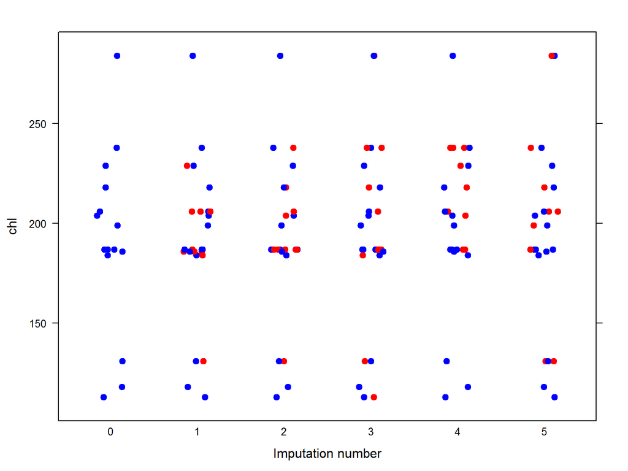

```r
com <-complete(imp, "long", inc=T) #extracts 5 imputed datasets
col <- rep(c("blue","red")[1+as.numeric(is.na(imp$data$chl))],6) #distinguishes between observed and imputed values (blue and red)
stripplot(chl~.imp, data=com, jit=TRUE, fac=0.8, col=col, pch=20, cex=1.4, xlab="Imputation number")
```

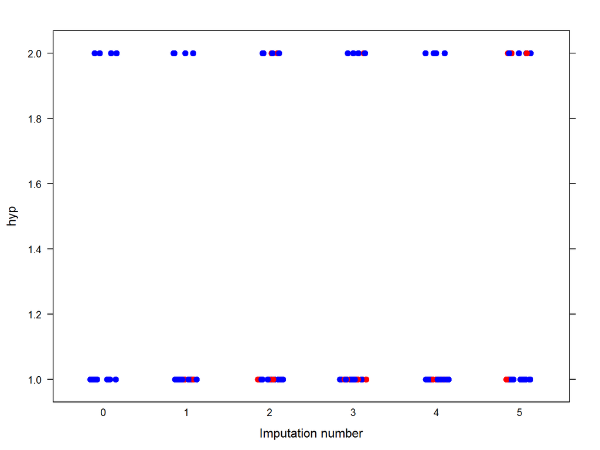

```r
#hyp
com <-complete(imp, "long", inc=T) #extracts 5 imputed datasets
col <- rep(c("blue","red")[1+as.numeric(is.na(imp$data$hyp))],6) #distinguishes between observed and imputed values (blue and red)
stripplot(hyp~.imp, data=com, jit=TRUE, fac=0.8, col=col, pch=20, cex=1.4, xlab="Imputation number")
```

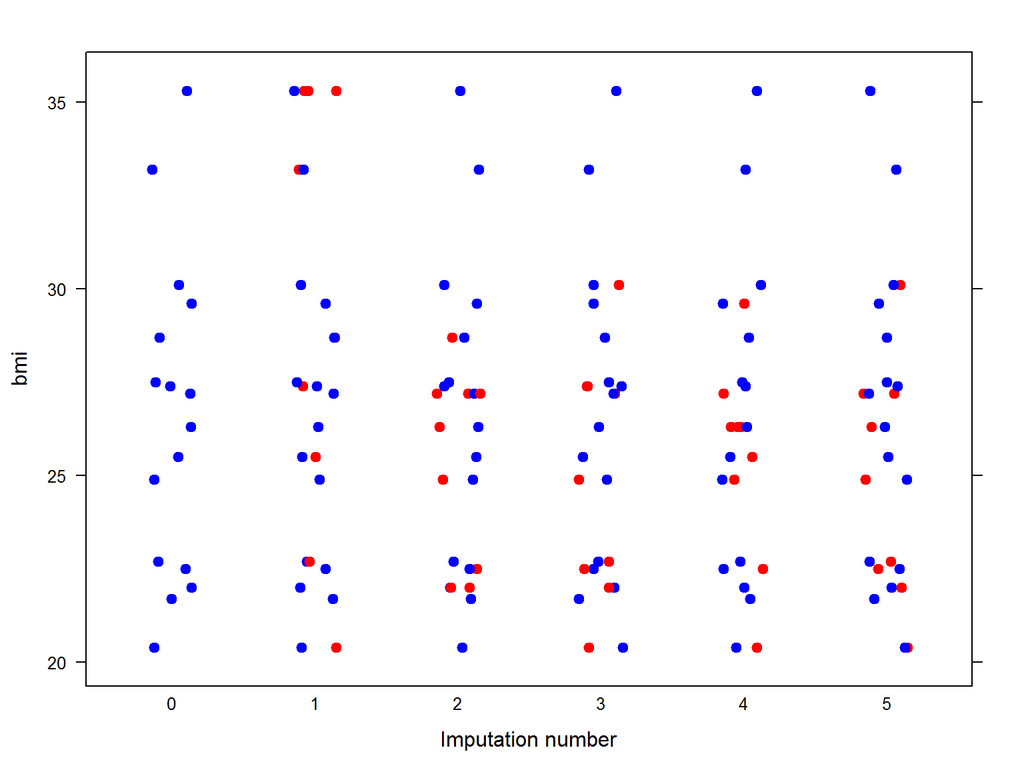

```r
#bmi
com <-complete(imp, "long", inc=T) #extracts 5 imputed datasets
col <- rep(c("blue","red")[1+as.numeric(is.na(imp$data$bmi))],6) #distinguishes between observed and imputed values (blue and red)
stripplot(bmi~.imp, data=com, jit=TRUE, fac=0.8, col=col, pch=20, cex=1.4, xlab="Imputation number")
```

```r
#This is an example of what MCAR should look like. It may look different for MAR and MNAR and you are referred to the excellent resource to learn about other ways to look at missing data patterns and diagnosis of imputation (https://www.jstatsoft.org/article/view/v045i03)
```

## Analysis of imputed data using a linear regression model

```r
fit <-with(imp, lm(chl~age+bmi)) #get regression coefficients
pool(fit) #pool regression coefficients and standard errors
```

```
## Call: pool(object = fit)
##
## Pooled coefficients:
## (Intercept)         age         bmi
##   -1.223182   33.087333    5.224215
##
## Fraction of information about the coefficients missing due to nonresponse:
## (Intercept)         age         bmi
##   0.5946212   0.6217931   0.4645532
```

```r
summary(pool(fit)) #more detail
```

```
##                   est        se           t       df   Pr(>|t|)
## (Intercept) -1.223182 77.761429 -0.01572994 6.448523 0.98792534
## age         33.087333 12.417304  2.66461494 5.973824 0.03745113
## bmi          5.224215  2.272765  2.29861632 9.148490 0.04665798
##                     lo 95     hi 95 nmis       fmi    lambda
## (Intercept) -188.33605207 185.88969   NA 0.5946212 0.4857731
## age            2.67098375  63.50368    0 0.6217931 0.5133284
## bmi            0.09555575  10.35287    9 0.4645532 0.3590308
```

## Specifying imputation models correctly can be challenging. Here are some considerations.

1. Decide whether MAR assumption is realistic. There are additional assumptions that can be used for MNAR (see the excellent resource on MICE)
2. The model form needs to be specified for each incomplete column of data (each variable)
   - default methods are listed in the table

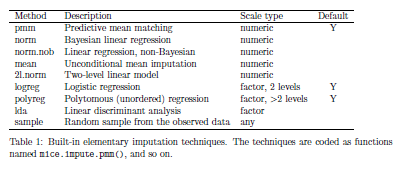

## Specifying imputation models correctly can be challenging. Here are some considerations (cont.)

3. Decide on variables to include as predictors in the impuation model. Include as many predictors as possible and their interactions OR at least include those that will be included in your regression model. Also include the dependent variable (J Graham, 2014)
4. Decide whether to impute variables that are “functions of other incomplete variables”
5. Decide whether you should specify an order in which the variables should be imputed
6. Decide on the number of iterations (not discussed further here)
7. Decide on the number of multiply imputed datasets. The default for m is 5 but if m is too low, it may result in p-values that are too low.
- **The default choices used in our example may not be best for your data**

## Resources for further reading

- I am indebted to these terrific methodologists below for helping me develop the content for this class!!
- Cummings,P. Missing Data and Multiple Imputation. 2013;167(7):656-661. doi:10.1001/jamapediatrics.2013.1329
- Van Buuren S, Groothuis-Oudshoorn K. mice: Multivariate Imputation by Chained Equations in R. 2011, 45(3):file:///C:/Users/kijohnson/Downloads/v45i03.pdf
- Graham JW. Missing Data Analysis. Making it Work in the Real World.Annu. Rev. Psychol. 2009. 60:549-576

## GOOD LUCK!!

[figure not shown]